# K-Nearest Neighbors (KNN)

You are as good as your closest friends

Son Nguyen

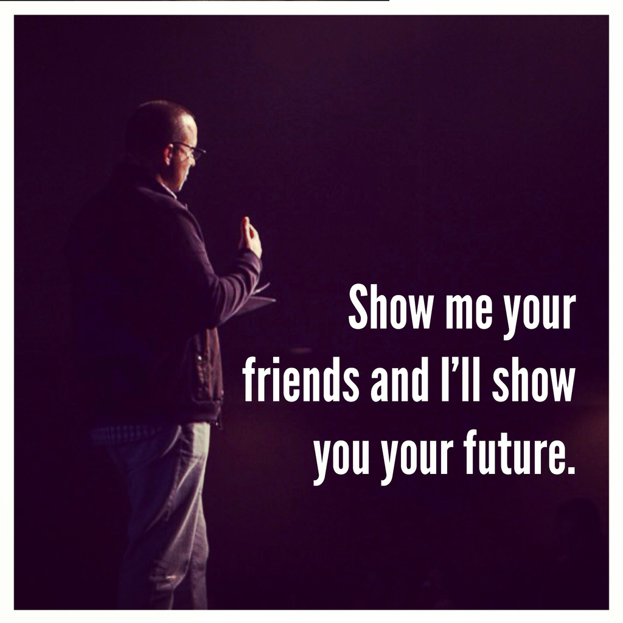

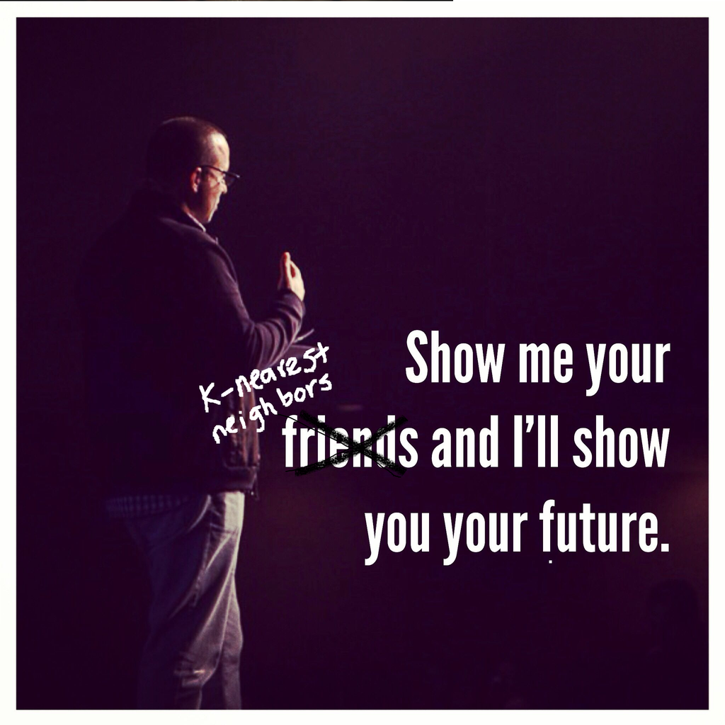

## Example: 1-Nearest Neighbor

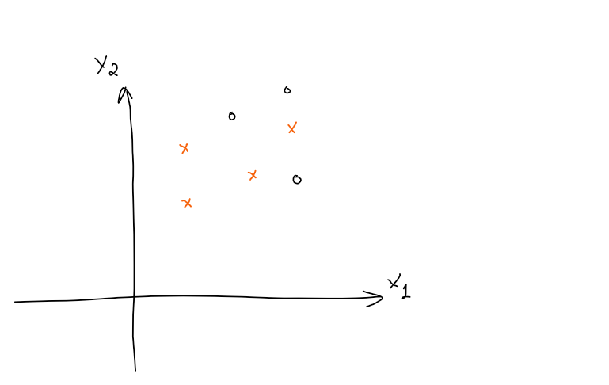

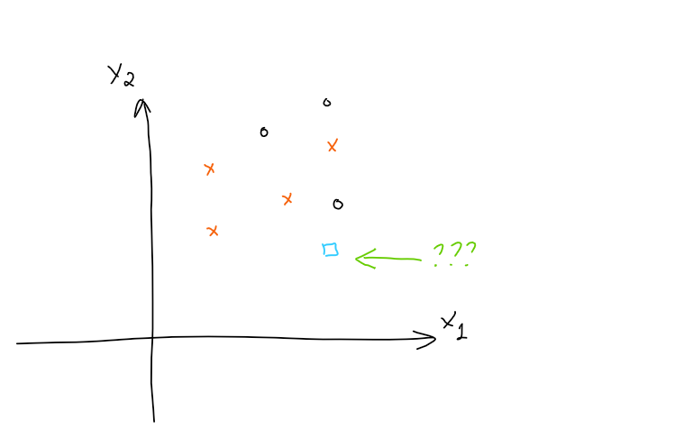

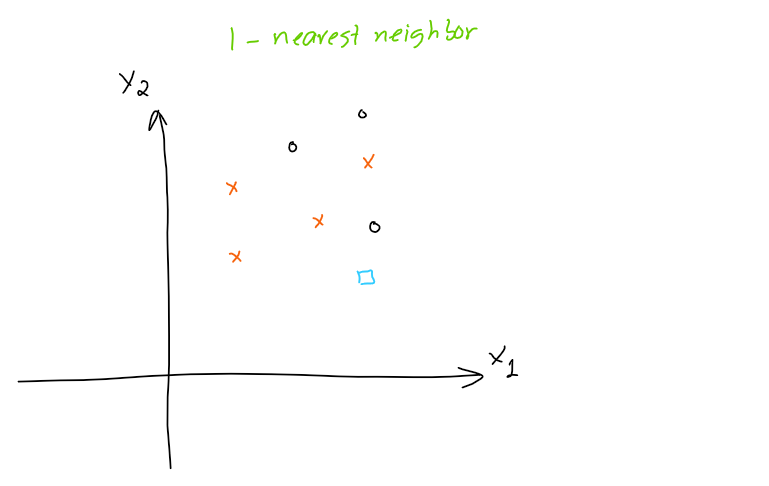

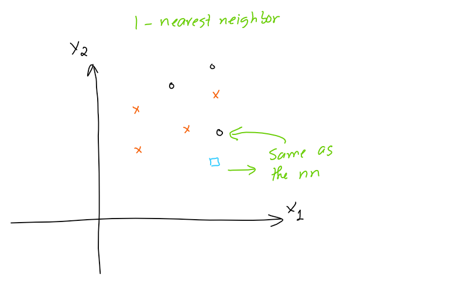

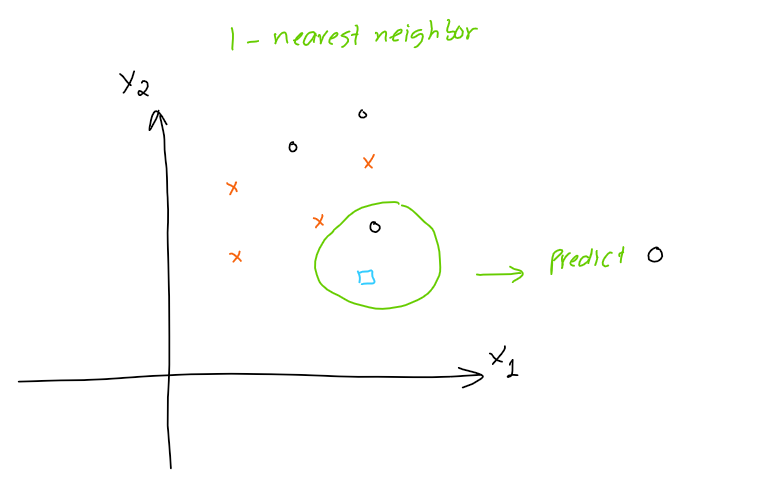

Given the training data.

Predict the class of the new sample.

“You are as good as your best (closest) friend!”

Find its single nearest neighbor.

The 1NN model classifies the new sample as $o$, since its nearest neighbor is an $o$.

## Example: 3-Nearest Neighbors

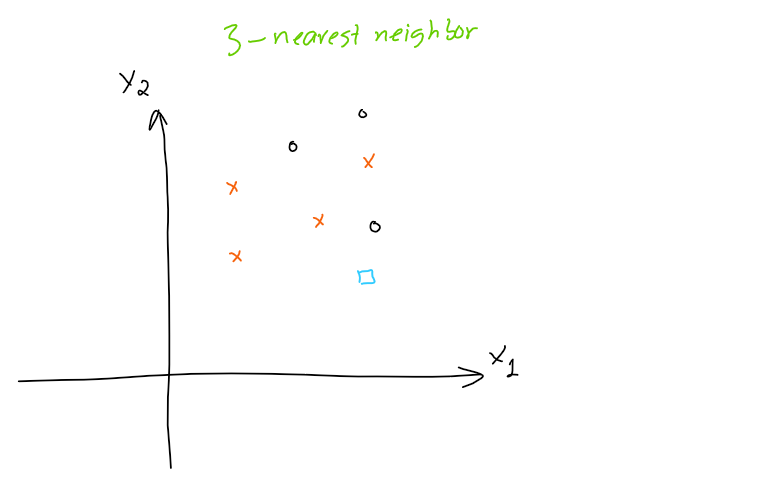

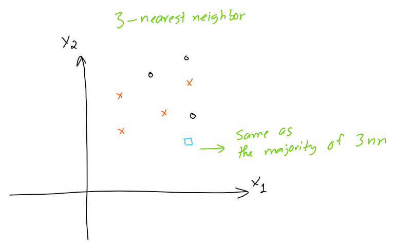

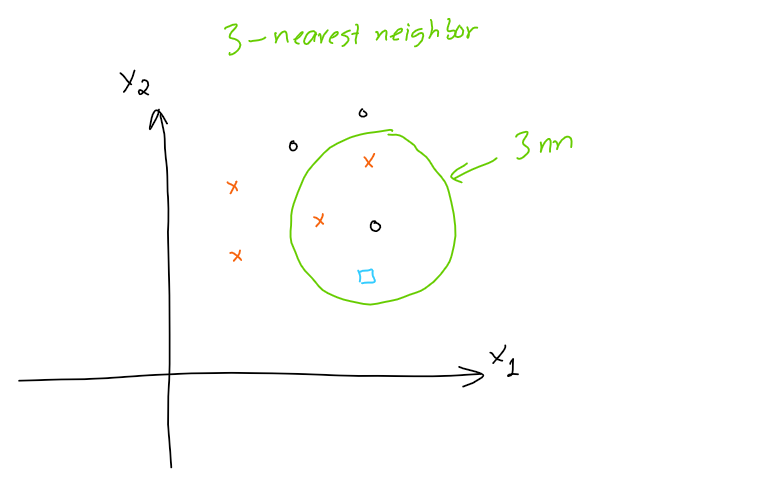

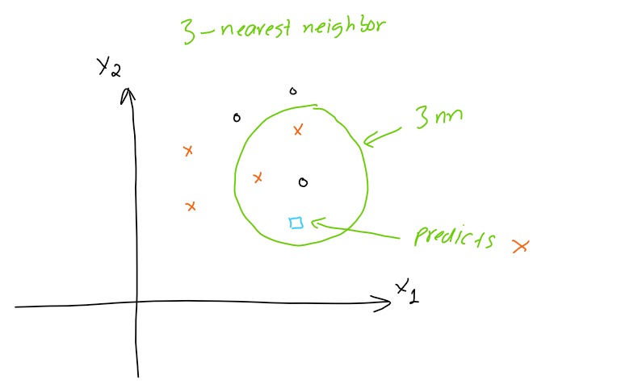

Now look at the 3 nearest neighbors.

Grow the neighborhood…

…until it contains 3 training points.

The 3NN model classifies the new sample as $x$, since the majority (2 of 3) of its nearest neighbors are $x$.

## KNN: Prediction Rule

- **Prediction rule**: look at the $K$ training examples most similar (closest) to the new point.
- For **classification**: predict the *majority* class among the $K$ neighbors (majority vote).
- For **regression**: predict the *average* response of the $K$ neighbors.

KNN has no training step: the “model” is the training data itself. All the work happens at prediction time (a *lazy* learner).

## KNN Algorithm

- **Step 1**: Standardize the variables (compute the scaling from the *training* data, then apply the same scaling to the test point).
- **Step 2**: Compute the distance from the test point to every training point.
- **Step 3**: Sort the distances in ascending order.
- **Step 4**: Select the $K$ training points with the smallest distances: the $K$ nearest neighbors.
- **Step 5**: Use majority vote (classification) or averaging (regression).

## Algorithm Requirements

The algorithm requires:

- **Tuning parameter $K$**: the number of nearest neighbors to use.
- **Distance function**: to measure how similar two examples are.

## Two Ways to Measure “Close”

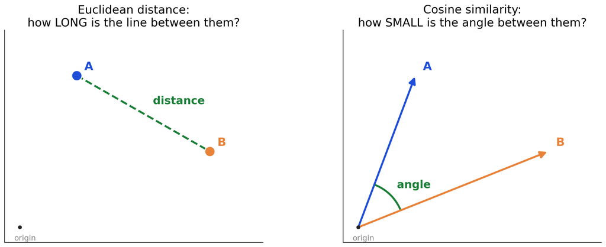

- **Short line** = close.
- Cares about *where* the points are.
- **Small angle** = close (similarity near 1).
- Cares only about the *direction* the points are in, not how far out they are.

## Same Points, Different Nearest Neighbor

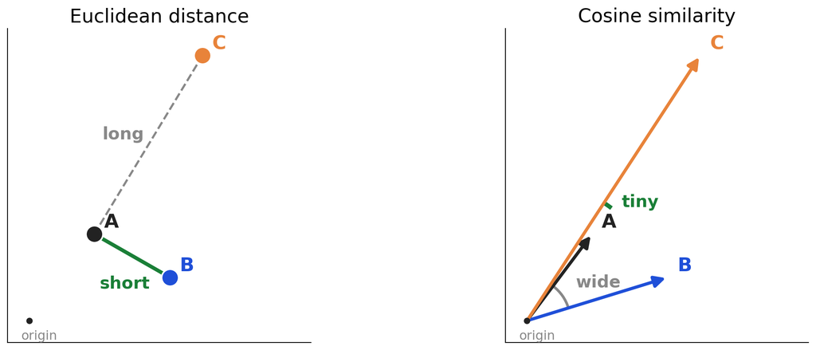

**Question:** What is the nearest neighbor of A?

- Length matters: C is farther out, so it is far from A.
- **Closest neighbor of A is B.**
- Length does not matter: only the direction counts.
- **Closest neighbor of A is C.**

The two measures can pick **different** nearest neighbors, so KNN can give different predictions depending on which one we use.

## The Range of Cosine Similarity: From $-1$ to $1$

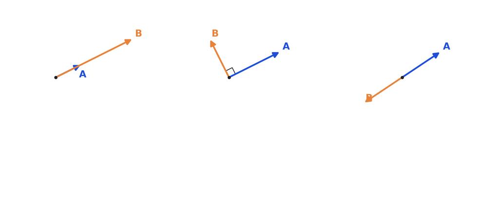

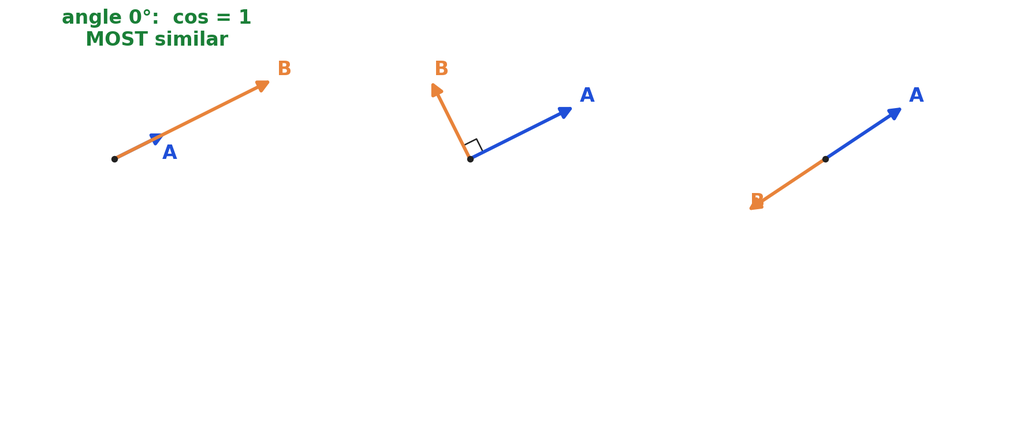

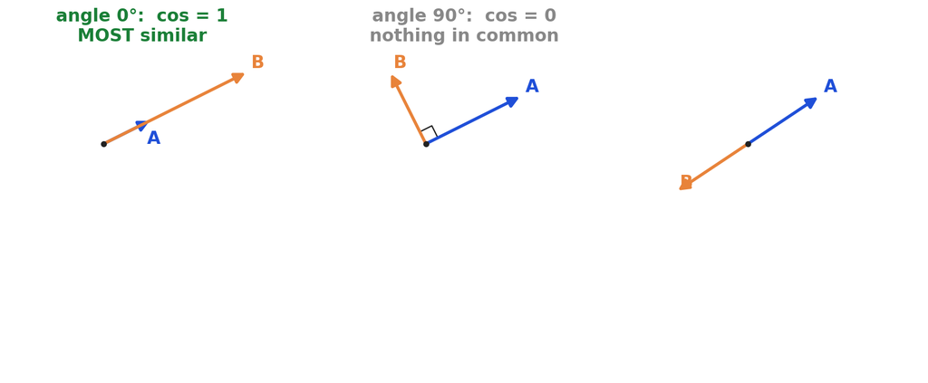

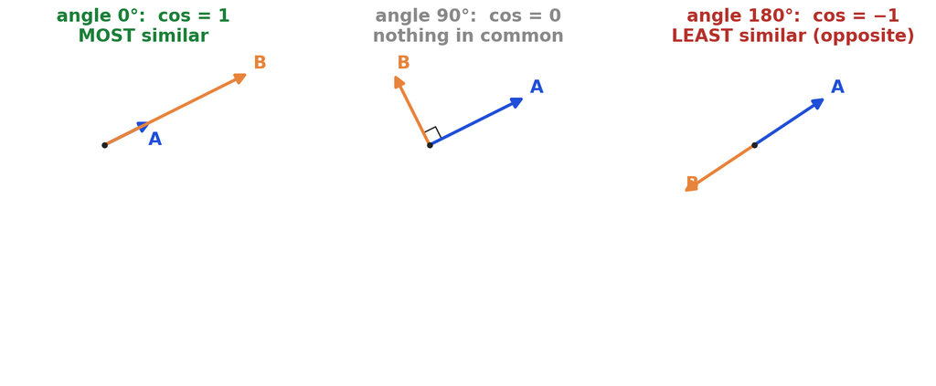

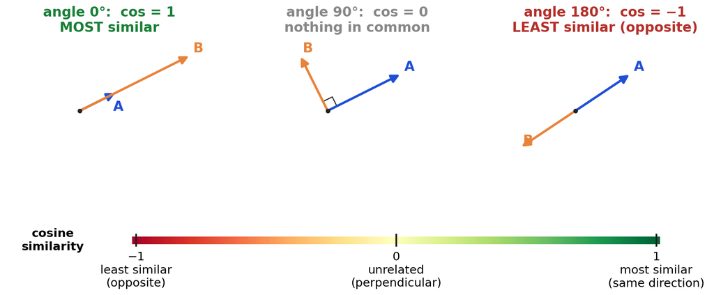

## Using Cosine Similarity in KNN

The algorithm is the same. Only Steps 2–4 change:

- **Step 2**: Compute the **cosine similarity** between the test point and every training point.
- **Step 3**: Sort the similarities in **descending** order (largest first).
- **Step 4**: The $K$ nearest neighbors are the $K$ training points with the **largest** similarities.
- **Step 5**: Majority vote (classification) or average (regression), as before.

Equivalently, use cosine distance $1 - \cos$ and keep the original “smallest first” algorithm.

## When Is Cosine the Better Choice?

When the *pattern* (the mix of the variables) matters but the overall *size* does not:

- word counts in documents (a long article and a short one on the same topic),
- ratings or purchases (a heavy user and a light user with the same taste),
- embeddings (song, movie, or text vectors in modern recommender systems).

## Example: Sports or Politics?

Each news article is described by how many times two words appear: $x_1$ = count of **“game”**, $x_2$ = count of **“vote”**.

| Article | $x_1$ (“game”) | $x_2$ (“vote”) | Class |
| --- | --- | --- | --- |
| A | 8 | 2 | Sports |
| B | 10 | 3 | Sports |
| C | 6 | 1 | Sports |
| D | 1 | 3 | Politics |
| E | 2 | 5 | Politics |
| **New** | **3** | **1** | **?** |

1. Use 3NN with **Euclidean distance** to classify the new article.
2. Use 3NN with **cosine similarity** to classify the new article.
3. The two answers differ. Which one makes more sense, and why?

## Solution (a): Euclidean Distance

Example calculation, New $= (3, 1)$ and A $= (8, 2)$: $\; d = \sqrt{(3 - 8)^2 + (1 - 2)^2} = \sqrt{26} \approx 5.099$

| Article | $(x_1, x_2)$ | Class | Euclidean distance to New | Rank (smallest first) |
| --- | --- | --- | --- | --- |
| A | (8, 2) | Sports | 5.099 | 4 |
| B | (10, 3) | Sports | 7.280 | 5 |
| **C** | (6, 1) | Sports | **3.000** | 2 |
| **D** | (1, 3) | Politics | **2.828** | 1 |
| **E** | (2, 5) | Politics | **4.123** | 3 |

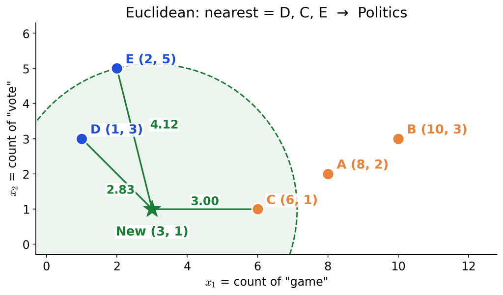

- The 3 nearest neighbors are **D, C, E**: two Politics, one Sports.
- **Prediction: Politics** (2 of 3 votes).

## Solution (b): Cosine Similarity

Example calculation, New $= (3, 1)$ and A $= (8, 2)$: $\; \cos = \dfrac{3 \cdot 8 + 1 \cdot 2}{\sqrt{3^2 + 1^2}\,\sqrt{8^2 + 2^2}} = \dfrac{26}{\sqrt{10}\,\sqrt{68}} \approx 0.997$

| Article | $(x_1, x_2)$ | Class | Cosine similarity with New | Rank (largest first) |
| --- | --- | --- | --- | --- |
| **A** | (8, 2) | Sports | **0.997** | 2 |
| **B** | (10, 3) | Sports | **1.000** | 1 |
| **C** | (6, 1) | Sports | **0.988** | 3 |
| D | (1, 3) | Politics | 0.600 | 5 |
| E | (2, 5) | Politics | 0.646 | 4 |

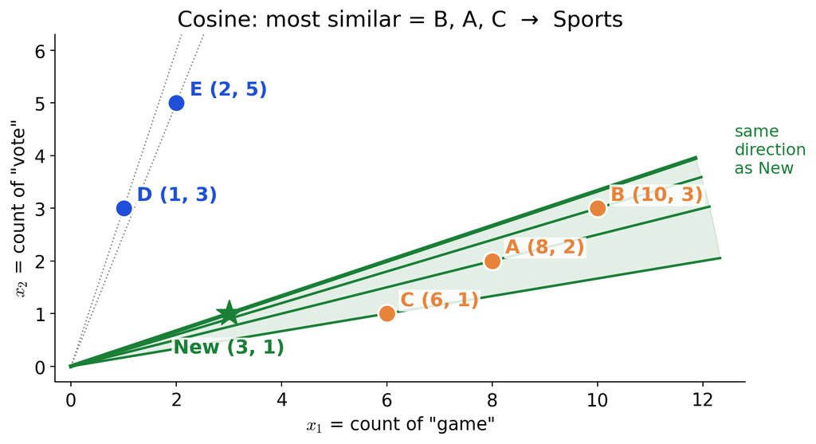

- The 3 most similar articles are **B, A, C**: all three Sports.
- **Prediction: Sports** (3 of 3 votes).

## Side by Side: Euclidean vs. Cosine

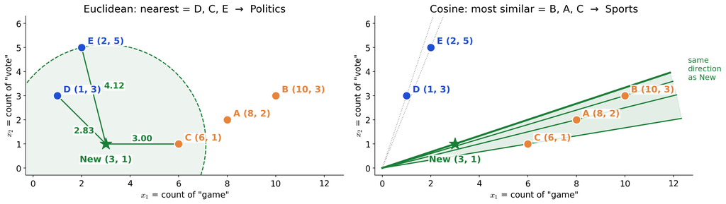

- **Euclidean** looks for points *near* the new point. **Cosine** looks for points in the same *direction* from the origin.

## Solution (c): Which Answer Makes More Sense?

|  | Euclidean distance | Cosine similarity |
| --- | --- | --- |
| Neighbors | D, C, E | B, A, C |
| Prediction | Politics | **Sports** |
| What it compares | the actual counts | the **mix** of words |

- The new article uses “game” **3 times as often** as “vote”, just like the sports articles (8:2, 10:3, 6:1).
- It is simply **short**. D and E are also short, so they are close in Euclidean distance, even though they use “vote” more than “game”.
- Cosine ignores length (how many words in total) and compares the **proportions**, so it gets the topic right: **Sports**.

Euclidean distance mixes up “different topic” with “different length”. Cosine similarity answers only “same topic?”. For word counts, ratings, and embeddings, that is usually the right question.

## How Cosine Similarity Relates to Euclidean Distance

Expand the squared Euclidean distance:

$$\|\mathbf{a} - \mathbf{b}\|^2 = \|\mathbf{a}\|^2 + \|\mathbf{b}\|^2 - 2\, \mathbf{a} \cdot \mathbf{b} = \|\mathbf{a}\|^2 + \|\mathbf{b}\|^2 - 2\, \|\mathbf{a}\|\, \|\mathbf{b}\| \cos(\mathbf{a}, \mathbf{b})$$

Now **normalize** every vector to length 1: $\hat{\mathbf{a}} = \mathbf{a} / \|\mathbf{a}\|$. Then $\|\hat{\mathbf{a}}\| = \|\hat{\mathbf{b}}\| = 1$, and

$$\|\hat{\mathbf{a}} - \hat{\mathbf{b}}\|^2 = 2 - 2\cos(\mathbf{a}, \mathbf{b}) = 2\,\big(1 - \cos(\mathbf{a}, \mathbf{b})\big)$$

- When the vectors have length 1, a **larger** cosine similarity means a **smaller** Euclidean distance, always.
- So the two methods find **the same nearest neighbors** once every vector is normalized.
- The two methods only disagree when the vectors have **different lengths**, as in our example.

Cosine similarity = Euclidean distance after shrinking (or stretching) every vector to length 1.

## Check It on Our Example

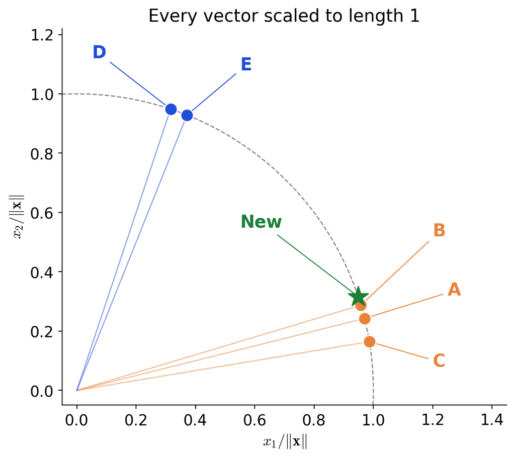

New normalized: $(0.949, 0.316)$

| Article | Normalized | $\cos$ | Distance after normalizing | $\sqrt{2(1 - \cos)}$ |
| --- | --- | --- | --- | --- |
| **B** | $(0.958, 0.287)$ | 1.000 | **0.030** | 0.030 |
| **A** | $(0.970, 0.243)$ | 0.997 | **0.077** | 0.077 |
| **C** | $(0.986, 0.164)$ | 0.988 | **0.156** | 0.156 |
| E | $(0.371, 0.928)$ | 0.646 | 0.841 | 0.841 |
| D | $(0.316, 0.949)$ | 0.600 | 0.894 | 0.894 |

- The last two columns match, as the formula says.
- After normalizing, the 3 nearest by Euclidean distance are **B, A, C**: the same as cosine, so the prediction is **Sports**.

## More Ways to Measure Distance or Similarity

| Measure | Formula | Close when | Typical use |
| --- | --- | --- | --- |
| **Euclidean** ($L_2$) | $\sqrt{\sum (a_i - b_i)^2}$ | small | numeric variables (standardized) |
| **Manhattan** ($L_1$) | $\sum \lvert a_i - b_i \rvert$ | small | numeric; less sensitive to one large difference |
| **Minkowski** ($L_p$) | $\left(\sum \lvert a_i - b_i \rvert^p\right)^{1/p}$ | small | $p = 1$: Manhattan; $p = 2$: Euclidean |
| **Chebyshev** ($L_\infty$) | $\max_i \lvert a_i - b_i \rvert$ | small | only the single largest difference matters |
| **Cosine similarity** | $\dfrac{\mathbf{a} \cdot \mathbf{b}}{\\|\mathbf{a}\\|\, \\|\mathbf{b}\\|}$ | large | text, ratings, embeddings |
| **Pearson correlation** | cosine of the *centered* vectors $\mathbf{a} - \bar{a}$, $\mathbf{b} - \bar{b}$ | large | ratings: removes each user’s average (generous vs. harsh raters) |
| **Hamming** | number of positions where $a_i \ne b_i$ | small | binary or categorical variables |

Any similarity $s$ with maximum 1 becomes a distance with $1 - s$ (for example, cosine distance and correlation distance).

## Example: One Pair, Many Measures

Two points: $A = (1, 1)$ and $B = (4, 3)$. To go from A to B: $3$ steps across and $2$ steps up.

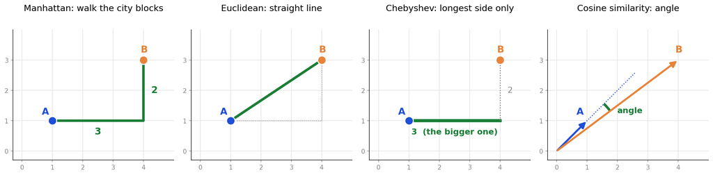

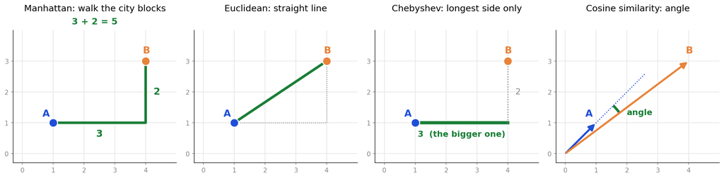

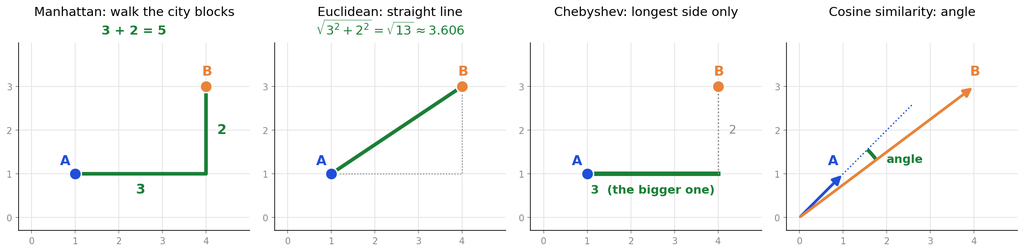

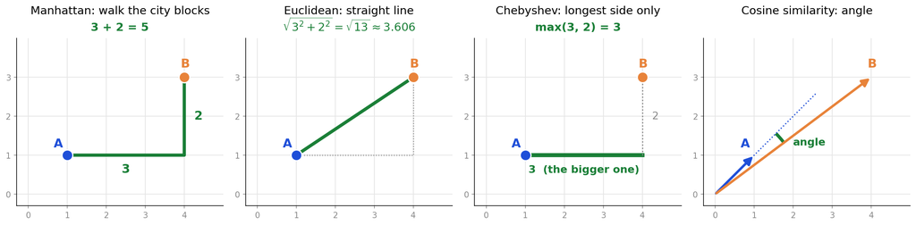

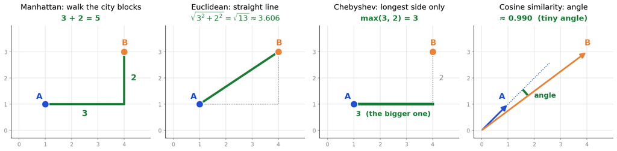

- **Minkowski** is a dial between them: $p = 1$ is Manhattan, $p = 2$ is Euclidean, and as $p$ grows it approaches Chebyshev. For $p = 3$: $(3^3 + 2^3)^{1/3} \approx 3.271$.
- The distances line up: Chebyshev $3 \;\le\;$ Minkowski ($p = 3$) $3.271 \;\le\;$ Euclidean $3.606 \;\le\;$ Manhattan $5$.
- **Cosine** sees A and B as very similar ($0.990$): they point in nearly the same direction, even though B is farther out.

## Example: Binary Data (Hamming Distance)

Two users, 6 movies. A filled square = watched, an empty square = not watched.

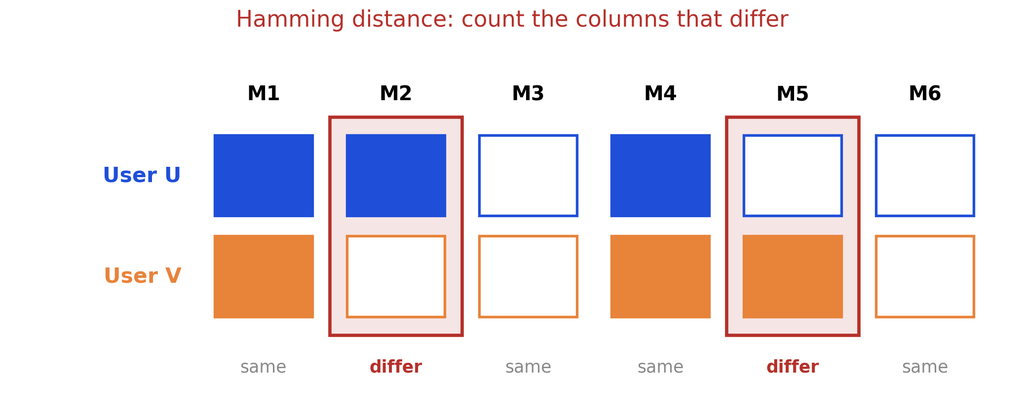

**Hamming distance $= 2$**

## Choosing the Measure in Python

```python
from sklearn.neighbors import KNeighborsClassifier

X_docs = [[8, 2], [10, 3], [6, 1], [1, 3], [2, 5]]          # articles A to E
y_docs = ["Sports", "Sports", "Sports", "Politics", "Politics"]

for metric in ["euclidean", "manhattan", "chebyshev", "cosine"]:
    knn = KNeighborsClassifier(n_neighbors=3, metric=metric).fit(X_docs, y_docs)
    print(f"{metric:>10}: {knn.predict([[3, 1]])[0]}")
```

```
 euclidean: Politics
 manhattan: Politics
 chebyshev: Politics
    cosine: Sports
```

- Other options: `metric="minkowski", p=3`; `metric="hamming"` for binary data; `metric="correlation"`.
- Remember to **standardize** numeric variables for the $L_p$ distances. Cosine already ignores each vector’s length.

## Choice of $K$: Neighborhood Size

- **Question**: Does a larger or a smaller $K$ tend to overfit?

## Choice of $K$: Neighborhood Size

- **Question**: Does a larger or a smaller $K$ tend to overfit?
- **Hint**: Which one performs better on the training data? (What is the training error of 1NN?)

## Choice of $K$: Neighborhood Size

- **Small $K$**
  - Creates many small regions for each class.
  - Leads to jagged decision boundaries and **overfitting** (1NN has zero training error).
- **Large $K$**
  - Creates fewer, larger regions.
  - Leads to smoother decision boundaries; too smooth can **underfit** ($K = n$ always predicts the overall majority class).

Choose $K$ by cross-validation. For binary classification, an odd $K$ avoids tied votes.

## Decision Boundaries as $K$ Grows

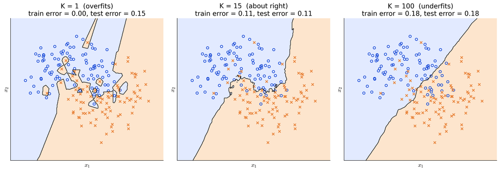

- $K = 1$: training error is exactly 0, but the boundary chases noise. $K = 100$: the boundary is too smooth to follow the curved classes.

## Training vs. Test Error as $K$ Changes

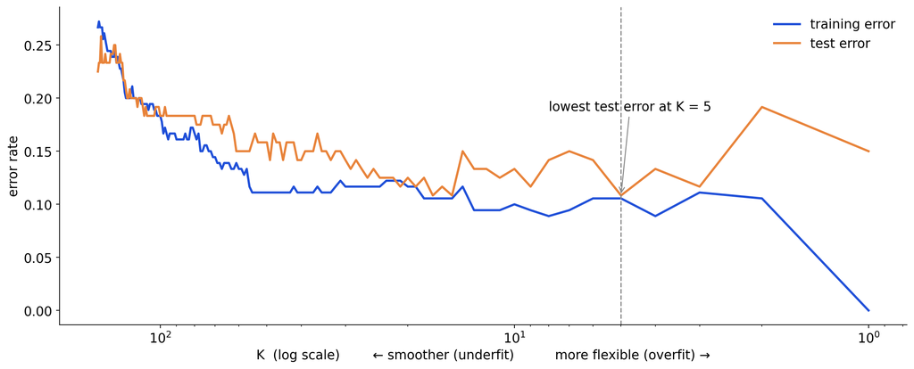

- Training error keeps falling as $K$ shrinks (reaching 0 at $K = 1$); test error is U-shaped. Pick $K$ near the bottom of the test (or cross-validation) curve.